# IODS Final project

Robert Leigh (robert.leigh@helsinki.fi)

18 December 2017

# Abstract

# Research question

I seek to use principal component analysis on the Boston data set to summarize the variables and visualize colinear variables. I also seek to test if principle component regression using the variables in the Boston dataset can be used to predict the amount of air pollution in different areas of Boston.

# Data wrangling

link: https://github.com/robertscottleigh/IODS-final/blob/master/create_final.R

# Description of the variables

The dataset is from the 1970 census in Boston, Massachussets. A description of the variables is shown below. They are related to factors affecting home value and air pollution in the Boston area. For this analysis, the data has been scaled so that the mean is equal to zero.

Variable descriptions (from https://www.cs.toronto.edu/~delve/data/boston/bostonDetail.html) crim = per capita crime rate by town zn = proportion of residential land zoned for lots over 25,000 sq.ft indus = proportion of non-retail business acres per town. chas = Charles River dummy variable (= 1 if tract bounds river; 0 otherwise). nox = nitrogen oxides concentration (parts per 10 million). rm = average number of rooms per dwelling. age = proportion of owner-occupied units built prior to 1940. dis = weighted mean of distances to five Boston employment centres. rad = index of accessibility to radial highways. tax = full-value property-tax rate per $10,000. ptratio = pupil-teacher ratio by town. black = 1000(Bk - 0.63)^2 where Bk is the proportion of blacks by town. lstat = lower status of the population (percent). medv = median value of owner-occupied homes in $1000s.

```r
library(ggplot2)
library(GGally)
library(pls)
boston_scaled <- read.table("C:/HY-Data/LEIGH/course material/introduction_to_open_data_science/IODS-final/final.txt", sep=",", header=TRUE)
```

# Exploration of the variables

```r
summary(boston_scaled)
```

```
##       crim                 zn               indus
##  Min.   :-0.419367   Min.   :-0.48724   Min.   :-1.5563
##  1st Qu.:-0.410563   1st Qu.:-0.48724   1st Qu.:-0.8668
##  Median :-0.390280   Median :-0.48724   Median :-0.2109
##  Mean   : 0.000000   Mean   : 0.00000   Mean   : 0.0000
##  3rd Qu.: 0.007389   3rd Qu.: 0.04872   3rd Qu.: 1.0150
##  Max.   : 9.924110   Max.   : 3.80047   Max.   : 2.4202
##       chas              nox                rm               age
##  Min.   :-0.2723   Min.   :-1.4644   Min.   :-3.8764   Min.   :-2.3331
##  1st Qu.:-0.2723   1st Qu.:-0.9121   1st Qu.:-0.5681   1st Qu.:-0.8366
##  Median :-0.2723   Median :-0.1441   Median :-0.1084   Median : 0.3171
##  Mean   : 0.0000   Mean   : 0.0000   Mean   : 0.0000   Mean   : 0.0000
##  3rd Qu.:-0.2723   3rd Qu.: 0.5981   3rd Qu.: 0.4823   3rd Qu.: 0.9059
##  Max.   : 3.6648   Max.   : 2.7296   Max.   : 3.5515   Max.   : 1.1164
##       dis               rad               tax             ptratio
##  Min.   :-1.2658   Min.   :-0.9819   Min.   :-1.3127   Min.   :-2.7047
##  1st Qu.:-0.8049   1st Qu.:-0.6373   1st Qu.:-0.7668   1st Qu.:-0.4876
##  Median :-0.2790   Median :-0.5225   Median :-0.4642   Median : 0.2746
##  Mean   : 0.0000   Mean   : 0.0000   Mean   : 0.0000   Mean   : 0.0000
##  3rd Qu.: 0.6617   3rd Qu.: 1.6596   3rd Qu.: 1.5294   3rd Qu.: 0.8058
##  Max.   : 3.9566   Max.   : 1.6596   Max.   : 1.7964   Max.   : 1.6372
##      black             lstat              medv
##  Min.   :-3.9033   Min.   :-1.5296   Min.   :-1.9063
##  1st Qu.: 0.2049   1st Qu.:-0.7986   1st Qu.:-0.5989
##  Median : 0.3808   Median :-0.1811   Median :-0.1449
##  Mean   : 0.0000   Mean   : 0.0000   Mean   : 0.0000
##  3rd Qu.: 0.4332   3rd Qu.: 0.6024   3rd Qu.: 0.2683
##  Max.   : 0.4406   Max.   : 3.5453   Max.   : 2.9865
```

In order to identify potential relationships between the variables, they were plotted against one another to allow visual exploration. As the later parts of the report focus on the variable ‘nox’, which represents the nitrogen oxides concentration, I will focus on those here. Positive correlations are seen betwen nox and the following variables: age, lstat, and indus. Negative correlations are seen between nox and rm, dis, and medv. One would expect these relationships to also be apparent on our PCA plots.

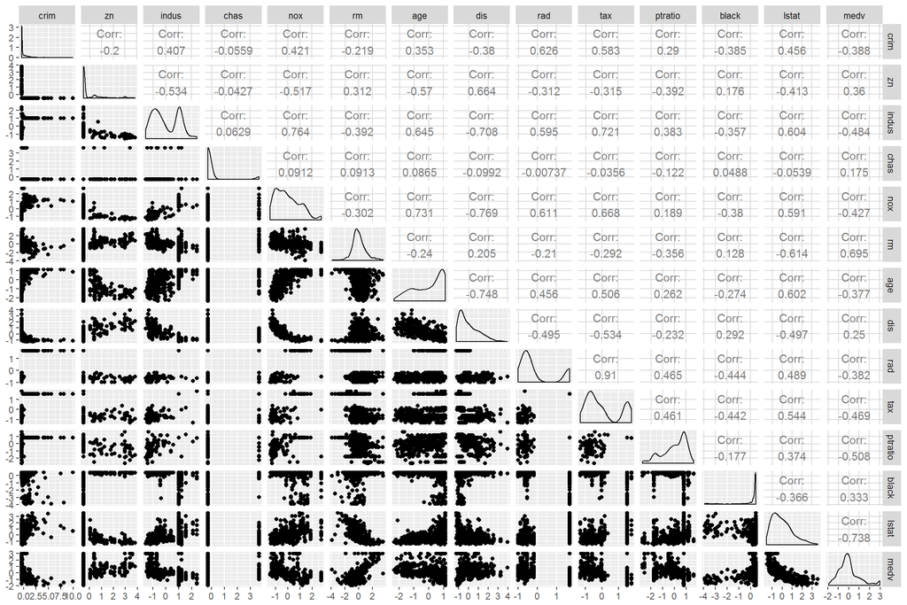

```r
ggpairs(boston_scaled)
```

# Brief description of the method (Principle component analysis/principle component regression)

Principle component analysis is a dimension reduction method. This means that it takes a dataset with high numbers of observations and high number of variables, and reduces it to a two dimensional plot. This is beneficial, in that it facilitates the understanding of the data by humans, who can only understand in 2-3 dimensions. Additionally, principle component analysis can be combined with regression to generate statistical models of the variables and to make predictions.

# Results of the analysis

```r
pca_boston_scaled <- prcomp(boston_scaled)
```

Principal component analysis was performed on the scaled data, and the 14 principal components and their standard deviations are shown below. Additionally, the rotation for each variable in the princiapl components is shown. The rotation value corresponds to the amount those variables affect that particular principle component direction. Those which are furthest from zero have the largest effects on that principle component. In principle component 1(PC1), the variables which most affect are ‘indus’, ‘nox’, ‘rad’, ‘tax’, and lstat. In principle component 2 (PC2), the variables which most affect are ‘chas’, ‘rm’, ‘dis’, ‘ptratio’, ‘medv’.

```r
pca_boston_scaled
```

```
## Standard deviations:
##  [1] 2.5585132 1.2843410 1.1614241 0.9415625 0.9224421 0.8124105 0.7317177
##  [8] 0.6348831 0.5265582 0.5022524 0.4612919 0.4277704 0.3660733 0.2456149
##
## Rotation:
##                  PC1          PC2          PC3          PC4          PC5
## crim     0.242284451 -0.065873108  0.395077419 -0.100366211  0.004957659
## zn      -0.245435005 -0.148002653  0.394545713 -0.342958421  0.114495002
## indus    0.331859746  0.127075668 -0.066081913  0.009626936 -0.022583692
## chas    -0.005027133  0.410668763 -0.125305293 -0.700406497 -0.535197817
## nox      0.325193880  0.254276363 -0.046475549 -0.053707583  0.194605570
## rm      -0.202816554  0.434005810  0.353406095  0.293357309 -0.008320481
## age      0.296976574  0.260303205 -0.200823078  0.078426326  0.149750092
## dis     -0.298169809 -0.359149977  0.157068710 -0.184747787 -0.106219480
## rad      0.303412754  0.031149596  0.418510334  0.051374381 -0.230352185
## tax      0.324033052  0.008851406  0.343232194  0.026810695 -0.163425820
## ptratio  0.207679535 -0.314623061  0.000399092  0.342036328 -0.615707380
## black   -0.196638358  0.026481032 -0.361375914  0.201741185 -0.367460674
## lstat    0.311397955 -0.201245177 -0.161060336 -0.242621217  0.178358870
## medv    -0.266636396  0.444924411  0.163188735  0.180297553 -0.050659893
##                 PC6          PC7         PC8          PC9         PC10
## crim    -0.22462703  0.777083366 -0.15740140  0.254211798 -0.071384615
## zn      -0.33574694 -0.274178365  0.38031404  0.382899480  0.245579673
## indus   -0.08082495 -0.340273839 -0.17174578  0.627048264 -0.254827026
## chas     0.16264906  0.074075775  0.03292700 -0.018642967 -0.041706916
## nox     -0.14899191 -0.198092965 -0.04745838 -0.043024391 -0.211620349
## rm       0.13108056  0.074084938  0.43761566 -0.003666947 -0.526133916
## age     -0.06086960  0.118580363  0.58810569 -0.043265822  0.245647942
## dis      0.01162335 -0.104397844  0.12823060 -0.175802196 -0.299412026
## rad     -0.13493732 -0.137080107 -0.07464872 -0.463439397  0.115793486
## tax     -0.18847146 -0.313984433 -0.07099212 -0.179446555 -0.008366413
## ptratio  0.27901731  0.001485608  0.28346960  0.274525949  0.160474164
## black   -0.78590728  0.074842780  0.04444175 -0.060975651 -0.146292237
## lstat   -0.09197211  0.083213083  0.35748247 -0.171810921  0.066647267
## medv    -0.05402804 -0.009964973 -0.15230879  0.070751083  0.575547284
##                 PC11        PC12         PC13         PC14
## crim    -0.071068781  0.06327612  0.097032312  0.059114176
## zn      -0.127709065 -0.22112210 -0.132375830 -0.096296807
## indus    0.273797614  0.34840828  0.083716854 -0.235472877
## chas    -0.009968402 -0.01903975 -0.049917454  0.023488966
## nox     -0.437475550 -0.44909357  0.524974687  0.087649148
## rm       0.223951923 -0.12560554 -0.049893596  0.007190515
## age     -0.329630928  0.48633905 -0.051462562 -0.038227027
## dis     -0.114600078  0.49356822  0.552292172  0.047124029
## rad      0.042213348  0.01863641 -0.006278474 -0.634975332
## tax      0.042794054  0.17042179 -0.242987756  0.698822190
## ptratio -0.099991841 -0.23214842  0.188347079  0.055738160
## black    0.039194858 -0.04152885 -0.021078199 -0.016165280
## lstat    0.683032690 -0.18189209  0.249489863  0.083143795
## medv     0.242001064  0.09828580  0.469629324  0.134127182
```

The summary of the PCA shows the variance explained by each principal components, as well as the standard deviation. The first two principal components explain 58.54% of the variance, as evidenced by the ‘cumulative proportion’ variable. The variance explained by each principal component becomes reduced with time. To achieve >90% of variance, 8 principal components are needed. As there was a starting point with 14 variables, principal component analysis was successful at reducing the number of dimensions. As I am new to PCA, I am not sure how these results reflect the suitability of PCA for this dataset. In general, one would hope as few principal components as possible could reflect a larger amount of variance.

```r
summary(pca_boston_scaled)
```

```
## Importance of components:
##                           PC1    PC2     PC3     PC4     PC5     PC6
## Standard deviation     2.5585 1.2843 1.16142 0.94156 0.92244 0.81241
## Proportion of Variance 0.4676 0.1178 0.09635 0.06332 0.06078 0.04714
## Cumulative Proportion  0.4676 0.5854 0.68174 0.74507 0.80585 0.85299
##                            PC7     PC8    PC9    PC10   PC11    PC12
## Standard deviation     0.73172 0.63488 0.5266 0.50225 0.4613 0.42777
## Proportion of Variance 0.03824 0.02879 0.0198 0.01802 0.0152 0.01307
## Cumulative Proportion  0.89123 0.92003 0.9398 0.95785 0.9730 0.98612
##                           PC13    PC14
## Standard deviation     0.36607 0.24561
## Proportion of Variance 0.00957 0.00431
## Cumulative Proportion  0.99569 1.00000
```

The principal component analysis is visualized by plotting the first principal component on the x-axis, and the second principal component on the y-axis. Individual observations are shown on the plot, as well as the variables with arrows. The observations which are in the direction of the arrows (variables) are most affected by those variables. Additionally, arrows(variables) pointing in similar directions affect variance similarly. In other words, those variables likely have correlations to one another. PCA thus allows showing in a single plot, both grouped observations and grouped variables. Colinearity seems to occur between age vs nox, rad vs tax, and medv vs rm. The closest variables to our main variable of interest, ‘nox’, are ‘age’ and ‘indus’. Age and industry had clear positive correlations with nox in our previous graphical exploration.

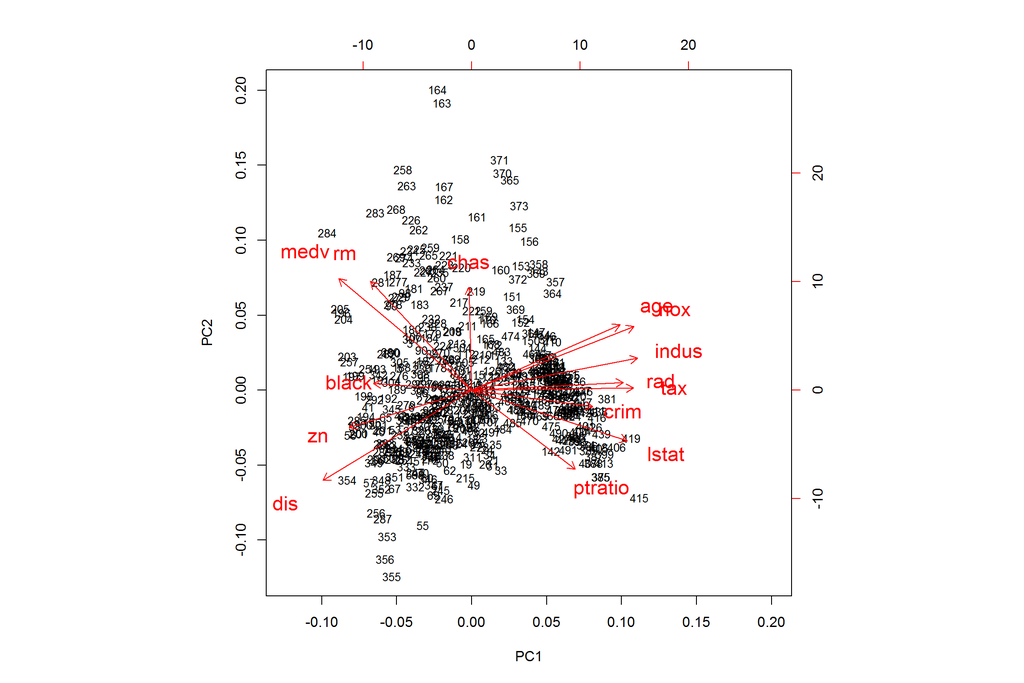

```r
biplot(pca_boston_scaled, choices = 1:2, cex=c(0.8, 1.4))
```

I will now seek to combine principal component analysis with linear regression. First, I divide the dataset into training and testing datasets. The training dataset contains 80% of the data, and the testing dataset contains 20% of the data. We will attempt to use the PCA model to examine the variable ‘nox’, which represents nitrogen oxide pollution.

```r
n <- nrow(boston_scaled)
ind <- sample(n,  size = n * 0.8)
boston_scaled.train <- boston_scaled[ind,]
boston_scaled.test <- boston_scaled[-ind,]
test_classes <- boston_scaled.test$nox
boston_scaled.test <- dplyr::select(boston_scaled.test, -nox)
```